# BELOWGROUND CONSEQUENCES OF VEGETATION CHANGE AND THEIR TREATMENT IN MODELS - Jackson - 2000 - Ecological Applications - Wiley Online Library

[Ecological Applications](https://esajournals.onlinelibrary.wiley.com/journal/19395582)

[Volume 10, Issue 2](https://esajournals.onlinelibrary.wiley.com/toc/19395582/2000/10/2) p. 470-483

[figure not shown]

Article

Full Access

# BELOWGROUND CONSEQUENCES OF VEGETATION CHANGE AND THEIR TREATMENT IN MODELS

[R. B. Jackson](https://esajournals.onlinelibrary.wiley.com/authored-by/Jackson/R.+B.),

[H. J. Schenk](https://esajournals.onlinelibrary.wiley.com/authored-by/Schenk/H.+J.),

[E. G. Jobbágy](https://esajournals.onlinelibrary.wiley.com/authored-by/Jobb%C3%A1gy/E.+G.),

[J. Canadell](https://esajournals.onlinelibrary.wiley.com/authored-by/Canadell/J.),

[G. D. Colello](https://esajournals.onlinelibrary.wiley.com/authored-by/Colello/G.+D.),

[R. E. Dickinson](https://esajournals.onlinelibrary.wiley.com/authored-by/Dickinson/R.+E.),

[C. B. Field](https://esajournals.onlinelibrary.wiley.com/authored-by/Field/C.+B.),

[P. Friedlingstein](https://esajournals.onlinelibrary.wiley.com/authored-by/Friedlingstein/P.),

[M. Heimann](https://esajournals.onlinelibrary.wiley.com/authored-by/Heimann/M.),

[K. Hibbard](https://esajournals.onlinelibrary.wiley.com/authored-by/Hibbard/K.),

[D. W. Kicklighter](https://esajournals.onlinelibrary.wiley.com/authored-by/Kicklighter/D.+W.),

[A. Kleidon](https://esajournals.onlinelibrary.wiley.com/authored-by/Kleidon/A.),

[R. P. Neilson](https://esajournals.onlinelibrary.wiley.com/authored-by/Neilson/R.+P.),

… See all authors

First published: 01 April 2000

https://doi.org/10.1890/1051-0761(2000)010[0470:BCOVCA]2.0.CO;2

Citations: 265

## Abstract

The extent and consequences of global land-cover and land-use change are increasingly apparent. One consequence not so apparent is the altered structure of plants belowground. This paper examines such belowground changes, emphasizing the interaction of altered root distributions with other factors and their treatment in models. Shifts of woody and herbaceous vegetation with deforestation, afforestation, and woody plant encroachment typically alter the depth and distribution of plant roots, influencing soil nutrients, the water balance, and net primary productivity (NPP). For example, our analysis of global soil data sets shows that the major plant nutrients C, N, P, and K are more shallowly distributed than are Ca, Mg, and Na, but patterns for each element vary with the dominant vegetation type. After controlling for climate, soil C and N are distributed more deeply in arid shrublands than in arid grasslands, and subhumid forests have shallower nutrient distributions than do subhumid grasslands. Consequently, changes in vegetation may influence the distribution of soil carbon and nutrients over time (perhaps decades to centuries). Shifts in the water balance are typically much more rapid. Catchment studies indicate that the water yield decreases 25–40 mm for each 10% increase in tree cover, and increases in transpiration of water taken up by deep roots may account for as much as 50% of observed responses. Because models are increasingly important for predicting the consequences of vegetation change, we discuss the treatment of belowground processes and how different treatments affect model outputs. Whether models are parameterized by biome or plant life form (or neither), use single or multiple soil layers, or include N and water limitation will all affect predicted outcomes. Acknowledging and understanding such differences should help constrain predictions of vegetation change.

## Introduction

Over the last few centuries the extent of land-use and land-cover change has been dramatic. Approximately 12 × 10<sup>6</sup> km<sup>2</sup> have been brought under cultivation since 1700, with grasslands and pasturelands declining by about half that amount (Turner et al. 1990). The rate of vegetation change is also increasing dramatically. The absolute depletion of forests and grasslands between 1950 and 1980 was greater than in the century and a half between 1700 and 1850 (Richards 1990). Accompanying the obvious changes aboveground are less conspicuous but equally important changes belowground. Plant life forms (e.g., grasses, shrubs, and trees) typically differ in the depth and distribution of their roots (Nepstad et al. 1994, Jackson et al. 1996), and most vegetation change occuring today alters the abundance of woody and herbaceous life forms. This paper examines the consequences of changes in belowground structure that accompany land-use and land-cover change.

The conversion of forests to crop and pasturelands remains a prevalent form of vegetation change. In the last three centuries ∼20% of existing forests and woodlands have disappeared (Richards 1990). Most current deforestation is tropical and subtropical, in part because many temperate forests were exploited previously (in Britain, for example, a commission for the iron-making industry studied the consequences of deforestation 450 years ago [Darby 1951]). Approximately 100 000 km<sup>2</sup> of forest in tropical America, Africa, and Asia are cleared annually (FAO 1995). In many tropical savannas, woody species are also declining (Hoffmann and Jackson 2000). In the Brazilian cerrado 700 000 km<sup>2</sup> have been cleared of woody vegetation, 40% of the total for the region (Klink et al. 1995). The loss of remaining cerrado is now ∼1% per year.

Reforestation and afforestation have also affected large areas. Approximately 250 000 km<sup>2</sup> of croplands in the United States reverted to forests this century (Williams 1990). In Europe, large-scale reforestation programs began in the 19th century (Mather 1993). Reforestation often creates managed forest plantations, frequently of introduced species, and these plantations almost always differ structurally and functionally from native forests (Mather 1993).

The expansion of woody vegetation into arid and semiarid systems is another common form of vegetation change that alters plant life forms. The phenomenon has been particularly rapid this century across broad areas of Argentina (e.g., León and Aguiar 1985), Australia (Harrington et al. 1984), central and southern Africa (van Vegten 1983), south-central Asia (Zonn 1995), and the deserts, grasslands, and savannas of North America (e.g., Buffington and Herbel 1965, Schlesinger et al. 1990, Archer 1995). The two most commonly cited causes are fire suppression and increased grazing (e.g., Foster 1917, Walker et al. 1981). One important difference between woody plant encroachment and other types of vegetation change is that deforestation and land-use conversion often happen quickly, while the expansion of woody plants typically occurs over decades to centuries. Consequently it is harder to document and attribute to a particular cause.

The premise of this paper is that the types of vegetation change occurring today alter the belowground structure of plants, and, consequently, the biogeochemistry and functioning of ecosystems. We begin by outlining differences in the belowground structure of plant life forms and how such differences affect soil attributes. We then examine some ecosystem consequences of vegetation change with an emphasis on the role of altered root distributions. Because of the importance of models in predicting the effects of vegetation change, we discuss different ways in which models treat belowground processes and the effect these differences have on model outputs and predictions. We end by highlighting ways in which the representation of belowground processes might be improved in models.

## Root and Soil Attributes for Plant Life Forms

### Different root distributions for woody and herbaceous plants

Differences in the distribution of roots among plant life forms have been observed for decades (e.g., Cannon 1911, Weaver 1919) and were likely clear even earlier (e.g., Theophrastus 300 BC, Hales 1727, Du Hamel Du Monceau 1764). The functional consequences of varied root distributions have also been inferred for decades. Weaver and Kramer (1932) examined the invasion of a tallgrass prairie by the more deeply rooted *Quercus macrocarpa* after fire suppression. Eugene Warming (1892) noted that leaf-out and sprouting by cerrado trees in Brazil often occurred prior to the first rains of the wet season and inferred that the plants were using water stored deep in the soil to initiate growth. Half a century later Felix Rawitscher (1948) documented the presence of tree roots and standing water at 18-m depth in the same region. Walter (1954) first proposed the two-layer model of water uptake for an African savanna, with grasses and woody plants partitioning soil water into relatively shallow and deep pools.

The relative importance of belowground net primary productivity (NPP) in many systems and potential differences among plant life forms have led to several recent summaries of root attributes. Vogt et al. (1996) and Cairns et al. (1997) examined root biomass and primary productivity for forest ecosystems. Sun et al. (1997) used drawings from the literature to compare morphological characteristics of 55 grassland species. Jackson et al. (1996, 1997) compiled a global database of climate, soil, and root attributes by depth to seek general patterns in root attributes and to improve the representation of roots in models. Root data from more than 300 studies were assembled by biome and plant life form and were fitted to an asymptotic model of vertical root distribution, *Y* = 1 − β<sup>*d*</sup>, where *d* is depth (in cm), *Y* is the cumulative root fraction from the soil surface to depth *d* (a proportion between 0 and 1), and β is the extinction coefficient (Gale and Grigal 1987). β is the only parameter estimated in the model. It provides a simple index of rooting distributions, with high β values (e.g., 0.98) indicating proportionally more roots at depth and low β values (e.g., 0.90) proportionally more near the surface.

In general, woody species tend to be more deeply rooted than grasses and herbs (e.g., Walter 1954). Based on the database described above, Jackson et al. (1996) found values for total root biomass of 0.952 for grasses and 0.970 and 0.978 for trees and shrubs, respectively. Cumulative root biomass in the top 30 cm of soil was ∼45% for shrubs but 75% for a typical grass. Fine root distributions were similar to those for total root biomass (β = 0.954, 0.975, and 0.976 for grasses, shrubs, and trees, respectively; Jackson et al. 1997).

Herbaceous and woody plants also have fundamentally different maximum rooting depths. Based on data from 250 studies Canadell et al. (1996) found that the average maximum rooting depth for grasses and herbs was 2–2.5 m, but maximum rooting depth of trees and shrubs was considerably deeper, 5 and 7 m on average. Sun et al. (1997) found that grasses had maximum rooting depths that were shallower on average than shrubs in North American grasslands.

Differences among rooting characteristics also exist within life forms. For example, patterns of root biomass allocation within forest ecosystems appear to depend partly on soil characteristics and climate (Vogt et al. 1996, Cairns et al. 1997), but there are also clear differences among groups of tree species (Köstler et al. 1968, Vogt et al. 1996). Differences in rooting depths within the same life form have also been documented for shrubs from arid environments (e.g., Cannon 1911, Markle 1917) and for grassland species (Weaver 1919, Shalyt 1950).

As discussed above, most of the vegetation change occurring today alters the proportion of woody and herbaceous plants, including the conversion of forests to pastures, the reduction of trees in tropical savannas, and woody plant encroachment in deserts, grasslands, and temperate and subtropical savannas (the extent of woody plant encroachment is evident in a comprehensive database of >175 references we compiled). Such life forms provide a tool for simplifying vegetation change in complex environments (Körner 1994). By adding or eliminating plant life forms, vegetation change may dramatically alter the zones of plant activity and the depths of plant influence in the soil (Jackson 1999).

### Soil nutrient distributions and their relationship to plant life forms

In addition to altered root distributions, vegetation change may alter the distribution of soil nutrients. As a soil-forming factor, plants affect the pattern and rate of rock weathering, the rate of organic inputs to the soil, and the distribution of soil nutrients spatially and temporally. Changes in plant life forms that alter root profiles and maximum rooting depths may consequently alter vertical nutrient distributions (Jama et al. 1998), including the soil C pool—the largest terrestrial pool of organic C (e.g., Schlesinger 1977, Trumbore 2000).

To examine the vertical distribution of soil chemical elements, and potential interactions with plant life forms and global change, we used the World Inventory of Soil Emission Potential Database (WISE) from the International Soil Reference and Information Centre (Batjes 1996) and the National Soil Characterization Database (NSCD) produced and updated by the U.S. Department of Agriculture (USDA 1994; see also Jobbágy and Jackson 2000). Together these inventories contain morphological, physical, and chemical data for thousands of soil profiles from all soil series in the United States and for many profiles globally. They also contain information on topography, vegetation, and land use for many sites. We examined the depth distributions of soil elements as presented in the databases for organic C, total N, extractable P, and exchangeable K, Ca, Mg, and Na. To examine the interaction of vegetation with the vertical distribution of soil nutrients, we compared soil profiles from semi-arid shrubland and grassland systems (precipitation from 250–500 mm/yr) and profiles from grasslands and forests in subhumid systems (500–1000 mm/yr). All sites were temperate (mean annual temperatures of 5°–20°C). Statistical differences were tested by *t* test for the different vegetation types.

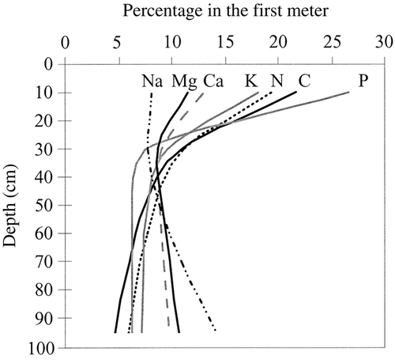

**Figure 1**

Global distributions with depth of soil organic C, total N, extractable P, and exchangeable K, Ca, Mg, and Na. The figure shows the relative amount of each element in the top meter of soil contained in each 10-cm increment of that top meter; a vertical line at 10% would show an element that is evenly distributed throughout the 1-m profile. P has the shallowest distribution, and Na has the deepest. Raw data are from the National Soil Characterization Database (USDA 1994) and from the World Inventory of Soil Emission Potential Database (Batjes 1996). Global distributions were calculated by averaging individual profiles within each soil order and weighting the average of each order according to its estimated global area (Eswaran et al. 1993). Since each profile did not include data for every element, the number of profiles used to calculate average distributions varied (C, 7362; N, 813; P, 296; K, 5786; Ca, 6015; Mg, 6054; Na, 4845)

If one were to predict the relative depth profiles in soil for base cations solely from their binding affinities to exchange sites and their likelihood of leaching (Sposito 1989, Schlesinger 1997), then the ranking of the shallowest to deepest elements would be Ca, Mg, K, and Na. In fact K was observed to be the most shallowly distributed of the four (Fig. 1); plants use and recycle proportionally more K than any other base. For example, the ratios of K to Ca, Mg, and Na in the WISE soil database were 0.23, 0.89, and 4.43 on average. The same ratios in plant material were more than an order of magnitude higher: 3.6, 10.1, and 99 for K:Ca, K:Mg, and K:Na, respectively, in a recent survey of 83 plant species (Thompson et al. 1997).

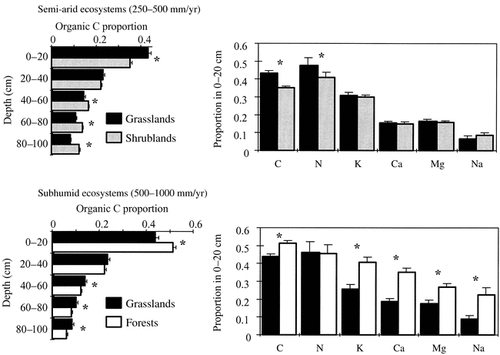

**Figure 2**

The depth distribution of soil organic carbon and nutrients in the top meter of soil under contrasting vegetation types. The top panels compare 44 grassland and 83 shrubland sites in semi-arid climates (250–500 mm precipitation per year). The bottom panels compare data for 36 grasslands and 87 forests in subhumid climates (500–1000 mm/yr). Panels on the left are the distribution of soil organic C in the top meter; those on the right are the proportion of soil elements in the top 20 cm of soil relative to the top meter. All sites are temperate, with mean annual temperatures of 5°–20°C. Elements are total organic C, total N, and exchangeable K, Ca, Mg, and Na. Differences indicated with an asterisk are significant at *P* < 0.05 (by *t* test). Raw data are from soil cores documented in the World Inventory of Soil Emission Potential Database (Batjes 1996) and the National Soil Characterization Database (USDA 1994)

## Root Distributions, Water Balance, and Vegetation Change

### Deforestation, afforestation, and woody plant encroachment

Deforestation, afforestation, and woody plant encroachment are three types of vegetation change prevalent today. The magnitude of their effects on carbon and water fluxes depends on a number of factors, including the degree and spatial extent of the change as well as the climate of the system. A summary of 94 catchment studies estimated a 40-mm decrease in water yield for each 10% increase in cover of conifers and eucalypts (the studies were generally in temperate North American systems, but a number of studies from Africa, Australia, and New Zealand were also included); analogous changes in hardwood and scrub communities were smaller but still substantial, 25- and 10-mm decreases respectively (Bosch and Hewlett 1982, incorporating data from Shachori and Michaeli 1965 and Hibbert 1967). Rooting depth is only one of numerous important factors associated with such changes, including potential differences in leaf area and phenology, albedo, surface roughness, and direct interception of precipitation.

The natural vegetation of southern Australia is characterized by *Eucalyptus* and other deep-rooted woody species (Canadell et al. 1996). For example, *E. marginata* has been shown to grow roots to 40 m depth (Dell et al. 1983), though 15–20 m seems more common (e.g., Kimber 1974, Carbon et al. 1980). Other trees and shrubs of the region, such as *Banksia,* are also quite deeply rooted (Crombie et al. 1988, Stone and Kalisz 1991). Much of this vegetation is evergreen, using relatively deep soil water to maintain a green canopy.

Across broad areas of southern Australia, deep-rooted, evergreen trees and shrubs have been replaced by more shallowly rooted pasture and crop species (e.g., Walker et al. 1993). The Murray-Darling Basin in southeastern Australia contributes almost half of that country's agricultural output and is >10<sup>6</sup> km<sup>2</sup> in size. Since European settlement in the early 1800s, almost two-thirds of its 700 000 km<sup>2</sup> of forest and woodlands have been converted to crop and pasturelands (Walker et al. 1993). Shrublands have been reduced by almost 30% from 190 000 km<sup>2</sup>. The consequences of this shift from woody to herbaceous vegetation are profound, including a dramatic rise in the water table (waterlogging in a number of places). Salinization from the higher water table and from irrigation has reduced the Basin's agricultural output by 20% (Anonymous 1990). Recent plans for amelioration include replanting half a billion trees and additional engineering projects in the region (e.g., building dams and using pipes to divert shallow groundwater to evaporation ponds).

There have been dramatic changes in the ecology and hydrology of southern Australia due to the changes in vegetation (Greenwood 1992). Pierce et al. (1993) and Hatton et al. (1993) modeled the hydrological consequences for ∼8000 km<sup>2</sup> of the Murray-Darling Basin. Simulated evapotranspiration (ET) from present-day systems compared to pre-European ones decreased by at least 10 mm per month in more than one-third of the area, with maximum decreases of 45 mm per month in valley bottom lands. In the authors' opinion the two most important factors causing the changes in hydrology were shifts in rooting depth and in the annual pattern of leaf area index (LAI; Pierce et al. 1993).

Similar phenomena of deforestation, rising groundwater, and salinization have also occurred in western Australia (e.g., Schofield 1992). In that region the replacement of native eucalypts with pasture increased soil water storage 219 mm in the first year alone of one study (Sharma et al. 1987). Since pasture roots were limited to the top 1–2 m of soil, almost all of the increased water storage came from below the 2-m maximum rooting depth of the pasture species. At a nearby site neutron probe measurements to 15 m showed that 20% of total summer ET in eucalypt forest came from water deeper than 6 m (Sharma et al. 1987). In southwestern Australia average annual transpiration in *E. camaldulensis* plots was 1148 mm, almost three times the annual rainfall of 432 mm (Marshall et al. 1997). The authors estimated that about one-third of the catchment needed to be replanted to eliminate rising groundwater there. Annual ET for crop and pasturelands in a different system was ∼400 mm/yr, while eucalypts transpired almost 2500 mm annually (Greenwood et al. 1985). This sixfold increase was attributed to the deep roots of the trees and to their evergreen nature. Similar dramatic changes occurred with pine afforestation (e.g., Greenwood et al. 1981).

The Mokobulaan experimental catchments of South Africa provide a 40-yr record of the effects of afforestation in grasslands (Van Lill et al. 1980). Eucalypt afforestation caused a stream with an average annual runoff of 236 mm to dry up completely nine years after planting; the stream in the pine catchment dried up in 12 years (Scott and Lesch 1997). Canopy interception could not have caused these changes, as it only increased from 115 mm/yr in the grassland to at most 130 and 175 mm/yr in the eucalypt and pine catchments, respectively. One fascinating result was a 5-yr delay in streamflow return after the eucalypts were cut. The authors concluded that two root-related factors were the likely cause for this delay (Scott and Lesch 1997). The first was that eucalypts mined deep-soil water reserves, drying out the catchment below levels necessary to generate streamflow (Dye 1996; see also Calder 1996 for a similar result in India). These layers needed to be refilled to restore the catchment's pretreatment hydrology. The second, related factor was that deep drainage increased along root channels after eucalypts were planted. Allison and Hughes (1983) showed that rain water penetrated to 12 m through root channels in an Australian eucalypt forest but to only 2.5 m in adjacent wheat fields.

Deforestation and vegetation change in South American forests can induce large changes in carbon and water fluxes. The importance of deep soil water for the transpiration, photosynthesis, and growth of woody plants in the Brazilian cerrado has been known for more than a century, with roots documented 18 m deep (Rawitscher 1948). Nepstad et al. (1994) recently examined the importance of rooting depth for productivity and water use in southern and eastern Amazonia. The natural vegetation is typically tropical evergreen forest with a pronounced dry season in most of the area. Using field experiments and satellite imagery the authors estimated that 10<sup>6</sup> km<sup>2</sup> of evergreen forest in Amazonia depended on deep roots for maintaining a green canopy. A critical link to the carbon and water cycles was the maintenance of leaf area in the dry season; leaf area in degraded pasture decreased by 68% during the dry period but by only 16% in adjacent undisturbed forest. More than three-quarters of the water transpired during the dry season in the forest came from below 2 m (250 mm of plant-available water). Areas of the Amazon without periodic drought would be unlikely to show the same result. Research on the hydrological impacts of Amazon deforestation in the ABRACOS project has also confirmed the importance of root distributions for soil moisture dynamics under forest and pasture (Nobre et al. 1996).

In arid and semiarid regions of the world where woody plant encroachment is common, the ratio of transpiration to soil evaporation is lower than in more mesic systems. Nevertheless, the encroachment of desert grasslands by woody plants can have important consequences for carbon and water fluxes (e.g., Aguiar et al. 1996). Hibbert (1983) compared water yield before and after shrub removal for 10 watersheds in California and Arizona; eliminating shrubs increased water yield ∼1 mm for each 4 mm increase in precipitation, mainly as increased subsurface flow and deep drainage. Such savings clearly depend on whether, and how much, herbaceous vegetation increases after shrub removal (Carlson et al. 1990). Kemp et al. (1997) examined soil water dynamics and ET along a 3000-m transect in the Chihuahuan desert of New Mexico. The dominant effect of vegetation on transpiration was through plant cover; transpiration as a proportion of total ET ranged from 40% in a sparse creosote community to >70%. After cover, the next most important factor was the depth and distribution of roots. Roots had only a modest effect on soil moisture in the upper 30 cm, but water loss from 60–100 cm was due almost exclusively to more deeply rooted species in the system.

In the Great Basin of the western United States, shrubs have been selectively removed to promote grass and forb growth since the middle of this century. A 20-yr experiment at the Stratton Sagebrush Hydrology Study Area examined the consequences of shrub removal for soil water storage (Sturges 1993). Twenty years after sagebrush removal, a doubling of grass production was still observed. The dominant change in soil water storage came from relatively deep soil layers (0.9–1.8 m). Sagebrush removal reduced soil water depletion by 24 mm during the growing season, all from below 0.9 m soil depth. This reduction represented ∼10% of growing season ET.

Water is perhaps the factor most limiting NPP globally (Lieth and Whittaker 1975). While water availability is controlled by many abiotic factors, biotic influences, such as changes in the abundance of woody and herbaceous vegetation, can also be important. Water use and its availability with depth affect the productivity of the landscape in concert with nutrient availability. Numerous ecological and biogeochemical models have been developed to analyze how changes in resource availability and climate influence the productivity of the biosphere.

## Modeling Belowground Aspects of Vegetation Change

### Treatment of root distributions and root functioning in ecosystem and biosphere models

The effects of vegetation change on such factors as NPP and ET can be predicted using ecological and biogeochemical models. In such models, the vertical distribution of roots in the soil is generally represented by one or two parameters: maximum rooting depth, which sets an upper boundary on the soil water available to plants, and the vertical distribution of roots, which allows water uptake to be partitioned based on relative amounts of roots at a particular depth. Treatment of these two factors in recent ecosystem and biosphere models and in land-surface parameterization schemes for general circulation models (GCMs) is summarized in Table 1. Not listed in the table are models that do not treat root distributions explicitly, such as Biome-BGC (Running and Hunt 1993), DOLY (Woodward et al. 1995), and CEVSA (Cao and Woodward 1998), which include a single term that lumps water availability with soil depth, rooting depth, and soil texture. Table 1 also includes the general approaches used to model root functioning, such as the uptake and transpiration of soil water.

Table 1. Treatment of root distributions and root functioning in ecological models and land surface parameterization schemes for global circulation models that incorporate different vegetation cover classes

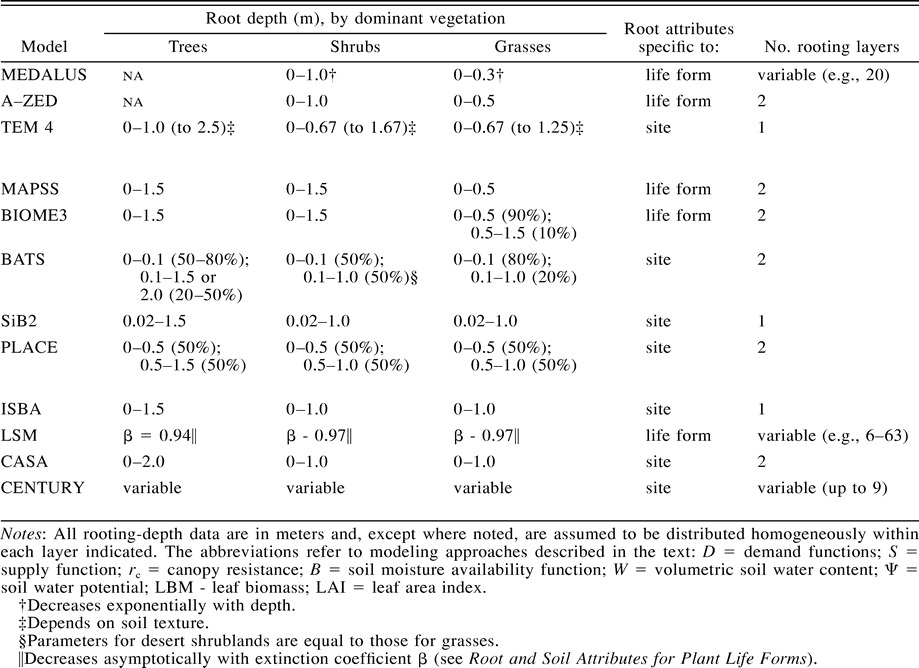

Table 1. Extended

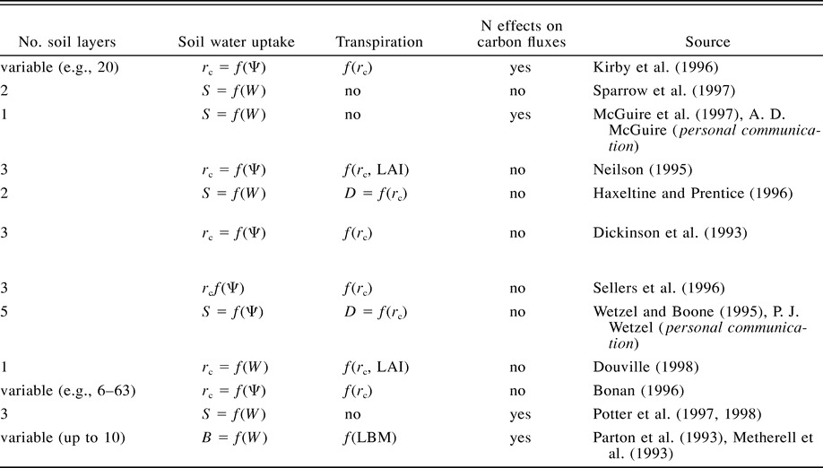

Current models use one of three general approaches to calculate soil water uptake by roots (Mahfouf et al. 1996): (1) the minimum of a demand (*D*) and a soil water supply (*S*) function, (2) a derivative of an Ohm's law model that calculates soil moisture effects on canopy resistance (*r*<sub>c</sub>), or (3) a direct function (*B*) of soil moisture availability. In all of these approaches soil moisture availability is calculated either as a function of volumetric soil water content (*W*) or of soil water potential (Ψ). In models such as BIOME3 (Haxeltine and Prentice 1996) and PLACE (Wetzel and Boone 1995) that calculate transpiration rates by the supply-demand method, canopy resistance is part of the demand function. Transpiration of water taken up by roots is modeled either as a function of canopy resistance (*r*<sub>c</sub>), leaf biomass (LBM), or leaf area index (LAI). For models that do not calculate transpiration rates, the function of rooting depth is to set an upper limit on the amount of soil water available for total ET. Another important function of roots, nutrient uptake, is considered in relatively few models, including TEM 4 (McGuire et al. 1997), CASA (Potter et al. 1997), and CENTURY (Metherell et al. 1993, Parton et al. 1993) (Table 1). In these models, soil nitrogen availability can influence primary productivity and other aspects of carbon fluxes.

The vertical distribution of nutrients is rarely treated in models (e.g., none of the models in Table 1). In our analyses we found consistent differences in vertical nutrient distributions, with potentially important implications for simulating some belowground processes. For example, we found the soil N pool to be consistently shallower than the pool of base cations, particularly the Ca and Mg pools, across different climates and plant life forms. If the rooting depth of an ecosystem increased, as with shrub encroachment into grasslands, the relative increase in the base cation pool should be larger than the relative increase in N. Such phenomena are not represented in current large-scale models.

Issues similar to those for simulating soil water uptake exist for simulating soil nutrient distributions and nutrient uptake with depth. Although nutrients are generally concentrated in the topsoil, the role of relatively deep nutrient pools may be important in some systems. In a secondary pine forest in South Carolina, Richter et al. (1994) were unable to balance the K uptake of plants using only the upper 0.6 m of soil; they suggested that the difference was explained by K absorption from deeper soil layers. Other authors have proposed that uptake from relatively deep K pools explains the higher than expected levels of K fertility in some forest systems (Alban 1982, Nowak et al. 1991).

Current models differ in the number of soil and root layers (Table 1). In some models, such factors as maximum rooting depth are inputs that are easily changed, while the number of soil layers is fixed. In a few models (e.g., Century, LSM, and MEDALUS) the number and depth of layers may be set by the user. Models that use a single soil layer face different issues than do models with multiple layers. In single-layer models root attributes mainly affect the total soil water storage capacity (in combination with soil texture) and the onset of drought stress; multilayer models need the vertical distribution of roots to estimate water uptake from different soil layers. Models with multiple layers differ in the root distributions that are used (Table 1). MAPSS (Neilson 1995), BIOME3 (Haxeltine and Prentice 1996), and PLACE (Wetzel and Boone 1995) tend to allocate roots relatively deeply in the soil (though with the majority of roots near the surface), while BATS allocates roots relatively shallowly, with 80–90% of roots in the upper 10 cm for grasses, desert communities, and evergreen, broad-leaved trees (Dickinson et al. 1993). Average field data are somewhat intermediate, suggesting that the depth to which 95% of root biomass occurs is ∼60 cm for grasses, 135 cm for shrubs, and 100 cm for trees (Jackson et al. 1996, 1997). However, the remaining roots at greater depth may be functionally quite important, especially for water uptake, justifying the assignments of relatively deep functional rooting depths in models that use a single rooting layer (Table 1).

There is another aspect of the structure of models that may have important implications for predictions. In some models, rooting attributes are site specific and do not account for differences among plant life forms coexisting at a site; other models assign root attributes by plant life form or functional type and allow for coexistence of plants with different root distributions (Table 1). This difference presumably affects predictions for vegetation dominated by mixtures of life forms, such as savannas and woodlands. For example, it would be difficult to model competition between deep-rooted woody plants and more shallowly rooted grasses during shrub encroachment into grasslands with a model that assigns rooting attributes to sites rather than to life forms.

Some potential problems in estimating root parameters from field data for models are that data are sparse for some biomes and also that the functional significance of roots at different depths may not always be proportional to root biomass or root length density. Kleidon and Heimann (1998) optimized rooting depths for vegetation units from data on climate and soil texture, rather than using field data to parameterize their model. Rooting depths were obtained by maximizing simulated long term mean NPP (incorporating cost–benefit calculations for carbon allocated to roots and water use efficiency of the vegetation). Predicted maximum rooting depths deviated substantially from biome data summarized in Canadell et al. (1996), but relative differences in rooting depths among biomes were predicted fairly well.

### Analyses of the sensitivity of models to root distributions

Modeling predictions of the effects of vegetation change on carbon and water fluxes depend on realistic characterizations of soil properties and root distributions, which together determine the amount of soil water available for ET. The sensitivity of predictions to accurate characterizations of the soil has been discussed by Patterson (1990), Dunne and Willmott (1996), and Bachelet et al. (1998). Here we focus on the effects of root distributions. Maximum rooting depth affects total soil water availability in GCM simulations, which in turn affects water and carbon fluxes. For example, Milly and Dunne (1994) found that global ET increased ∼70 mm/yr for a global doubling of water storage capacity in the soil. In the analysis of Dunne and Willmott (1996), rooting depth (as it influenced active soil depth) was the most influential and uncertain parameter in their global estimate of the plant-extractable water capacity of soil. Kleidon and Heimann (1998) compared runs of a terrestrial biosphere model with optimized rooting depths to runs with a constant rooting depth of 1 m for all global biomes. Compared to the constant rooting depth, global NPP for the optimized rooting depth increased by 16% and global ET increased by 18%.

The relative, vertical distribution of roots allows resource uptake to be partitioned based on the relative amounts of roots at depth (e.g., Liang et al. 1996, Desborough 1997). Some models use only the average bulk moisture availability in the rooting zone (e.g., Prentice et al. 1992, Woodward et al. 1995, Sellers et al. 1996, Douville 1998), but others apply a weighting scheme based on the proportion of roots in different layers (e.g., Dickinson et al. 1993, Wetzel and Boone 1995, Kirkby et al. 1996, Bonan 1996, 1998). Desborough (1997) used an off-line soil-moisture model and a complex Deardorff-type land-surface scheme to examine the effect of root weighting on transpiration. Varying the fraction of roots in the surface layer (0–10 cm) of the models from 10% to 90% resulted in relative annual differences in transpiration of up to 28%. As expected, vegetation was increasingly susceptible to water stress as the root fraction in the surface layer increased.

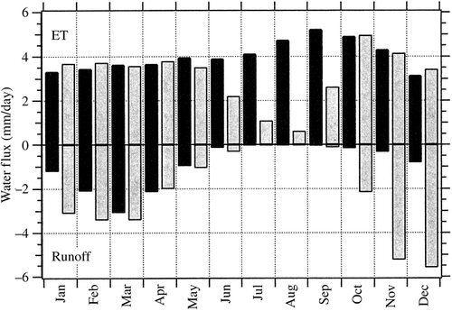

**Figure 3**

Seasonal course of evapotranspiration (positive values) and total runoff (surface runoff and drainage; negative values) averaged over Amazonia (taken as 75°–55° W, 0°–10° S). Simulations with a 1-m rooting depth are plotted as the gray bars, and those using deep (optimized) rooting depths are plotted as the solid bars

Until recently, root distributions have not generally received much treatment in modeling studies and in the publications describing the studies. For example, recent published comparisons of biogeography and biogeochemistry models (VEMAP Members 1995, Schimel et al. 1997, Pan et al. 1998) did not specify how rooting depths for different land covers were treated in the models. Detailed descriptions of root distributions and differences in the way models simulate resource uptake are often not included in publications (due in part to space constraints). The advent of web pages should improve the access of code and model logic to all users. Such information would be useful for comparing how models treat belowground processes, since one of the major conclusions from a comparison of 14 land-surface parameterization schemes (the PILPS-RICE workshop in Shao et al. 1995, Henderson-Sellers 1996, Shao and Henderson-Sellers 1996) was that the vertical layering of the soil and the extension of the root system was the most important factor explaining scatter among models because it set the amount of water available to plants in the simulations (Mahfouf et al. 1996). Douville (1998) also concluded that the prescriptions of rooting depth and soil depth are particularly important for predictions of global soil moisture dynamics. One aspect of root distributions not analyzed in the PILPS-RICE workshop was the integration of plant water availability over several root and soil layers. Shao et al. (1995) suggested that this may be an important difference among models, helping to explain fundamental differences in predicted water stress responses.

## Conclusions

As human population continues to increase, the transformation of the earth's vegetation is likely to continue. The scope of such changes and some of their consequences are increasingly visible (e.g., Turner et al. 1990, Vitousek et al. 1997). One consequence not so apparent is the altered structure of plants belowground, which affects water use, NPP, and the amount and distribution of soil carbon and nutrients.

There is both a need and an opportunity to improve the treatment of belowground processes in models. The need arises in part to understand the consequences of vegetation change and the novel combinations of climate and biota that will arise. Further studies to determine how well rooting depth and root distributions can be predicted from climate and soil data and from vegetation attributes such as life form would be beneficial. The opportunity is to incorporate recent advances in our knowledge of roots and belowground processes into models where appropriate. As an example, numerous data sets of soil texture are now available that should improve global estimates of water availability. Also, better feedbacks between field data collection and modeling needs could be encouraged, perhaps by funding agencies. Field experiments provide the data needed to run models, and modeling studies integrate results from field experiments and highlight gaps in our knowledge, stimulating further experiments. Future needs for modelers include better data on the extent and seasonal timing of N fixation, the conditions under which fine root density correlates with nutrient and water uptake, and the effects of soil attributes such as profile characteristics (e.g., horizons) and macroporosity on the flow of water and the presence of roots. As a specific example, do the relatively low root densities at depth reported for eastern Amazonia (Nepstad et al. 1994) account for observed dry-season transpiration, or must other processes such as hydraulic lift be invoked (Caldwell et al. 1998)?

Many global models do not contain explicit algorithms of belowground ecosystem structure and function, and it is unclear how much belowground detail is optimal for large-scale simulations. One way to evaluate this uncertainty would be a model intercomparison emphasizing belowground processes. Ecosystem processes such as NPP, net ecosystem productivity, and the water balance could be evaluated with different model formulations and parameterizations. Additionally, simulated predictions based on changes in plant life forms could be compared to field studies evaluating such changes. This type of comparison would fit well in the framework of the Global Analysis, Interpretation, and Modeling Project (GAIM) of the International Geosphere Biosphere Programme (IGBP).

Models provide one of the only methods for integrating the effects of global change. It is increasingly clear that for simulating some land surface processes a better representation of roots and the soil is needed. Improvements in the representation of roots, and better links between root and shoot functioning, should improve predictions of the consequences of vegetation and global change.

## Acknowledgments

Many of the ideas presented in this paper originated at a workshop of the Working Group “Towards an explicit representation of root distributions in global models” supported by the National Center for Ecological Analysis and Synthesis, a Center funded by NSF (DEB-94-21535), the University of California at Santa Barbara, and the State of California. R. B. Jackson acknowledges support from NCEAS, the National Science Foundation (DEB 97-33333), NIGEC/DOE, and the Andrew W. Mellon Foundation. L. J. Anderson, W. A. Hoffmann, and W. T. Pockman provided helpful comments on the manuscript. This research contributes to the Global Change and Terrestrial Ecosystems (GCTE) and Biosphere Aspects of the Hydrological Cycle (BAHC) Core Projects of the International Geosphere Biosphere Programme.

[Volume10, Issue2](https://esajournals.onlinelibrary.wiley.com/toc/19395582/2000/10/2)

April 2000

Pages 470-483